# Kapittel 6

## 6.1 Hva er greia?

- I dette kapitlet anvendes analysen fra kapittel 4 på risiko for å bli
  - arbeidsledig eller
  - fraværende fra arbeid av helsemessige årsaker (uføretrygd og sykefravær)
  - kapitlet fokuserer mest på hvorfor aktuarisk forsikring (en kontrakt der premien er lik forventet tap) ikke passer godt for disse risikoene, og peker mot tvungen sosialforsikring (Folketrygd) som en bedre tilnærming

### Velferdssstaten

- «Arbeidslinja» – med økt deltakelse i arbeidslivet – har vært en sentral målsetting i oppbyggingen av den norske velferdsstaten
- Sosialforsikring – Arbeidsledighetstrygd, Arbeidsavklaringspenger(AAP), Sykepenger, Uføretrygd, (kap 6), Alderspensjon (kap 7)
  - å sikre inntekt mot uforutsette hendelser
  - **Utbetalinger er betinget på at en har betalt inn til folketrygden**
- Sosialhjelp (kap 8) – Fattigdom: enpersonshusholdning har mindre enn 50 prosent av medianinntekt i tre år
- Universelle ordninger (kap 8) – Grunnpensjoner, barnetrygd
- **Ikke forveksle kunnskap om institusjoner med å forstå den underliggende økonomiske teorien!**

### Hva er de store spørsmålene?

- Mål:
  - fattigdomsbekjempelse
  - forsikring
  - konsumglatting
- Spørsmål:
  - Hvorfor er det offentlig organisert?
  - Er dette forsikring?

### Arbeidsledighetstrygd (dagpenger)

- For å ha krav på dagpenger må man ha fått redusert arbeidstiden med minst 50 prosent
- krav til at man har tjent mer enn 1,5 G (grunnbeløp i folketrygden) de siste 12 månedene
  - G er fra 1.5.2022 på 111.477 kroner, slik at 1,5 G er 167.216 kroner.
  - eller du må ha tjent minst 3 G (334.431) i løpet av de siste 36 månedene.
- man må være registrert som arbeidssøker
- dagpengene er 2,4 promille av dagpengegrunnlaget
  - dette tilsvarer i gjennomsnitt 62,4 prosent av tidligere inntekt før skatt
  - Dagpenger beregnes ikke av inntekter som er større enn 6 G, det vil si 668.862 kroner.
    - Maksimal dagpengeutbetaling blir dermed 417.370 kroner per år. – Dagpengegrunnlaget består av arbeidsinntekt og eventuelle folketrygdytelser (dagpenger, foreldrepenger ved fødsel og adopsjon, omsorgspenger, opplæringspenger, pleiepenger,svangerskapspenger, sykepenger)

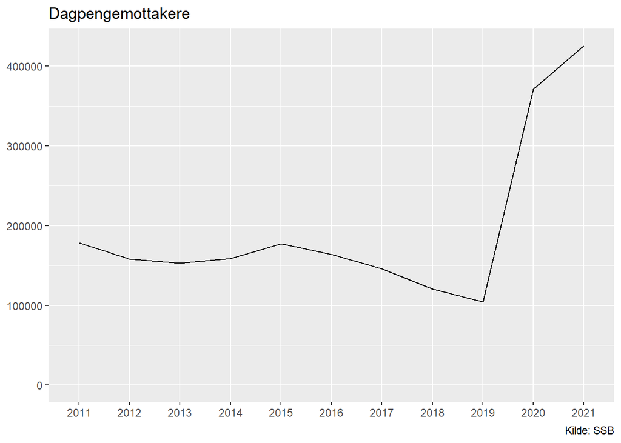

```r
library(PxWebApiData)
dp <- ApiData("https://data.ssb.no/api/v0/no/table/10454/",
                Inntekter225 = "05",
                LigningStatus = "B17+",
                Tid = c("2011", "2012", "2013", "2014", "2015", "2016", "2017", "2018", "2019", "2020", "2021"),
                ContentsCode="PersBelop")
library(tidyverse)
dp <- dp$dataset
dp%>%
  ggplot(aes(y=value, x=Tid,group=1)) +
  geom_line(stat="identity")+
  scale_y_continuous(limits = c(0, NA),labels = function(x) format(x, scientific = FALSE))+ # y axis starts from zero
  labs(title="Dagpengemottakere", caption = "Kilde: SSB")+
  theme(axis.title.x = element_blank(),
    axis.title.y = element_blank())
```

### Sykepenger

- Arbeidsgiveren utbetaler sykepenger for de første 16 kalenderdagene
- 100 % dekning: man kan få sykepenger som tilsvarer full lønn fra arbeidsgiveren din, men man har ikke rett til et sykepengegrunnlag som overstiger 6 G
- 52 uker makstid
- Egenmelding betyr at du melder fra til arbeidsgiveren din om at du er syk, uten at du leverer sykmelding
- Ved gradert (delvis) sykmelding har du rett til sykepenger for den delen du er syk
  - Sykepengene kan graderes fra 100 prosent og ned til 20 prosent

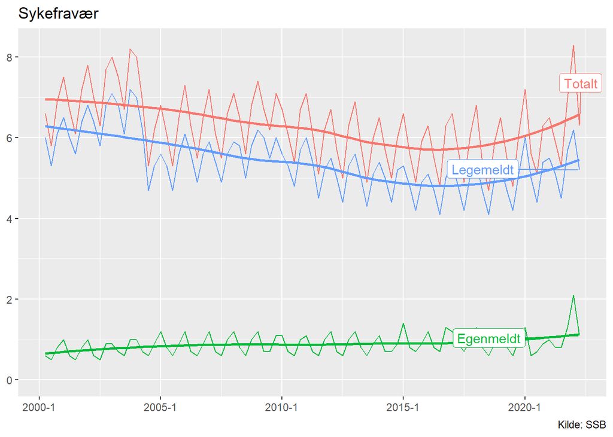

```r
library(PxWebApiData)
syk <- ApiData("https://data.ssb.no/api/v0/no/table/12440/",
              Kjonn = "0",
              Sykefraver2 = c("Alt","E","L"),
              NACE2007 = "A-U",
              Tid = c( "2000K2" , "2000K3" , "2000K4" , "2001K1" , "2001K2" , "2001K3" , "2001K4" , "2002K1" , "2002K2" , "2002K3" , "2002K4" , "2003K1" , "2003K2" , "2003K3" , "2003K4" , "2004K1",
                       "2004K2" , "2004K3" , "2004K4" , "2005K1" , "2005K2" , "2005K3" , "2005K4" , "2006K1" , "2006K2" , "2006K3" , "2006K4" , "2007K1" , "2007K2" , "2007K3" , "2007K4" , "2008K1",
                       "2008K2" , "2008K3" , "2008K4" , "2009K1" , "2009K2" , "2009K3" , "2009K4" , "2010K1" , "2010K2" , "2010K3" , "2010K4" , "2011K1" , "2011K2" , "2011K3" , "2011K4" , "2012K1",
                       "2012K2" , "2012K3" , "2012K4" , "2013K1" , "2013K2" , "2013K3" , "2013K4" , "2014K1" , "2014K2" , "2014K3" , "2014K4" , "2015K1" , "2015K2" , "2015K3" , "2015K4" , "2016K1",
                       "2016K2" , "2016K3" , "2016K4" , "2017K1" , "2017K2" , "2017K3" , "2017K4" , "2018K1" , "2018K2" , "2018K3" , "2018K4" , "2019K1" , "2019K2" , "2019K3" , "2019K4" , "2020K1",
                       "2020K2" , "2020K3" , "2020K4" , "2021K1" , "2021K2" , "2021K3" , "2021K4" , "2022K1" , "2022K2"),
              ContentsCode="SykefravProsent")

syk <- syk$dataset

library(tidyverse)
library(zoo)
library(ggrepel)
syk$Tid<-zoo::as.yearqtr(syk$Tid,format= "%YK%q")
syk$Sykefraver2 <- recode_factor(syk$Sykefraver2, Alt = "Totalt", E = "Egenmeldt", L = "Legemeldt")
data_ends <- syk %>% filter(Tid == "2022 Q2")
syk%>%
  ggplot(aes(y=value, x=Tid,group=factor(Sykefraver2),colour = factor(Sykefraver2))) +
  geom_line(stat="identity")+
  scale_y_continuous(limits = c(0, NA),labels = function(x) format(x, scientific = FALSE))+ # y axis starts from zero
  labs(title="Sykefravær", caption = "Kilde: SSB")+
  geom_smooth(aes(group = Sykefraver2), se = FALSE)+
  geom_label_repel(aes(label = Sykefraver2),data = data_ends,na.rm = FALSE,max.time = 5, force = 200, force_pull = 2)+
  theme(axis.title.x = element_blank(),
        axis.title.y = element_blank(),
        legend.position = "none",
        legend.title=element_blank())
```

## Arbeidsavklaringspenger

- skal sikre inntekt til personer mellom 18 og 67 år som på grunn av **sykdom**, **skade** eller **lyte** har fått nedsatt arbeidsevne
  - Arbeidsevnen skal være nedsatt med minst halvparten
- rettet mot personer med redusert arbeidsevne, og der det er mulighet for at arbeidsevnen kan bli bedre gjennom behandling, arbeidsrettede tiltak eller oppfølging fra NAV
- Målet med ordningen er å skaffe eller beholde arbeid og dermed unngå overgang til uføretrygd

```r
#######
## AAP#
#######
library(PxWebApiData)
#Check which variables that exist in the data.
variables_aap<-ApiData("https://data.ssb.no/api/v0/en/table/13058/",
                     returnMetaFrames = TRUE)
names(variables_aap)
```

```
[1] "Region"       "Kjonn"        "Alder"        "ContentsCode" "Tid"
```

```r
# Check which values each variable contains
values_aap<-ApiData("https://data.ssb.no/api/v0/en/table/13058/",
                       returnMetaData = TRUE)
#We check, which values "Alder" contains
values_aap[[3]]$values
```

```
[1] "18-67" "18-24" "25-34" "35-44" "45-54" "55-61" "62-67"
```

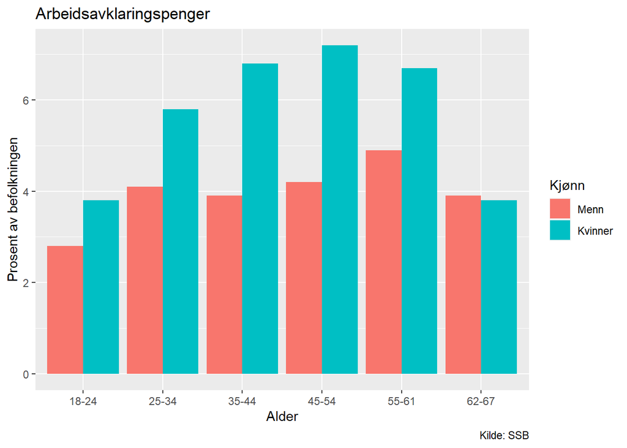

```r
# Define these variables in the query to sort out the values we want.
aap <- ApiData("https://data.ssb.no/api/v0/en/table/13058/",
                Kjonn = c("1","2"),
                Tid = "2021", # Define year to 2021
                Alder = c("18-24", "25-34", "35-44" ,"45-54", "55-61", "62-67"),
               ContentsCode="AapMottakPros")

library(tidyverse)
aap <- aap$dataset %>%
  filter(value!="NA")
aap$Kjønn <- factor(aap$Kjonn,
                    levels = c(1,2),
                    labels = c("Menn", "Kvinner"))
aap$Alder<-as.factor(aap$Alder)

aap%>%
  ggplot(aes(fill=Kjønn, y=value, x=Alder)) +
  geom_bar(position="dodge", stat="identity")+
  labs(title="Arbeidsavklaringspenger", caption = "Kilde: SSB", y = "Prosent av befolkningen", x = "Alder")
```

## Uføretrygd

- for å ha rett til å få uføretrygd, må sykdom og/eller skade være hovedårsaken til at man har nedsatt arbeids- og inntektsevne
- må som hovedregel fylle disse vilkårene:
  - må være mellom 18 og 67 år
  - må ha vært medlem av folketrygden de siste 5 årene før du ble syk eller skadet
  - må ha minst 50 prosent redusert arbeids- og inntektsevne
- må ha gjennomført
  - hensiktsmessig behandling som kan bedre arbeidsevnen
  - arbeidsrettede tiltak for å bedre inntektsevnen og avklare hvor mye man kan jobbe
- sammenlignet med andre land er det en høy andel av den voksne befolkningen i Norge som mottar uføreytelser

```r
# Uføretrygdede
#Check which variables that exist in the data.
variables_ufør<-ApiData("https://data.ssb.no/api/v0/en/table/11714/",
                       returnMetaFrames = TRUE)
names(variables_ufør)
```

```
[1] "Kjonn"        "Alder"        "UtdNivaa"     "ContentsCode" "Tid"
```

```r
# Check which values each variable contains
values_ufør<-ApiData("https://data.ssb.no/api/v0/en/table/11714/",
                    returnMetaData = TRUE)
#We check, which values "ContentsCode" contains
values_ufør[[4]]$values
```

```
[1] "UforetygdPers"  "UforetrygdPros"
```

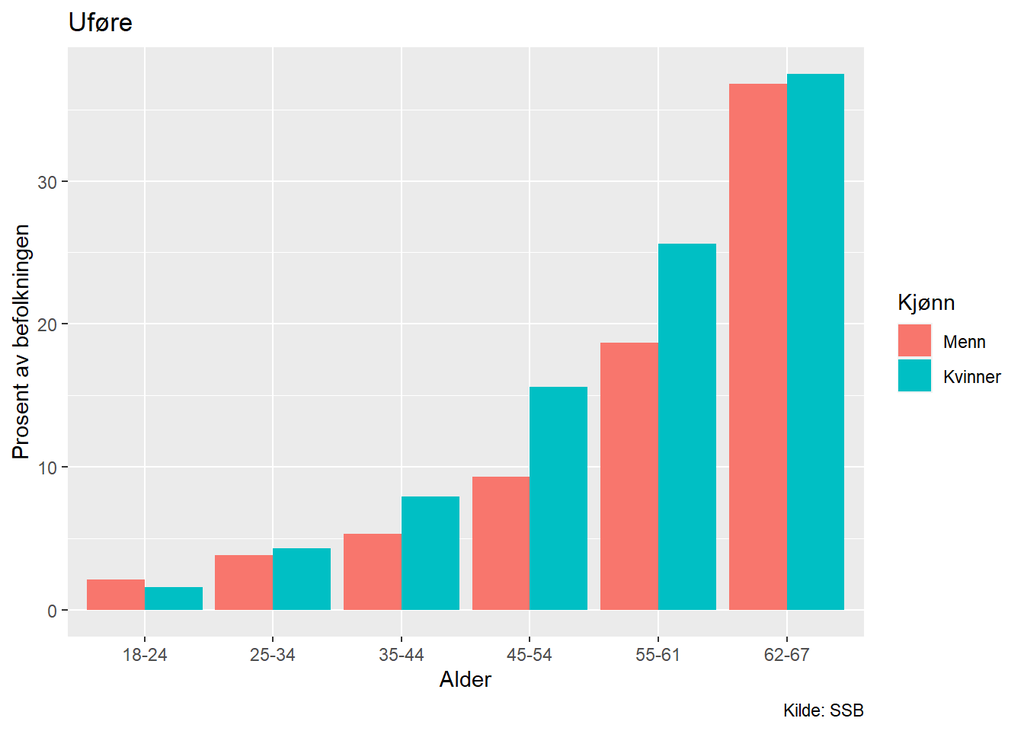

```r
ufør <- ApiData("https://data.ssb.no/api/v0/en/table/11714/",
               Kjonn = c("1","2"),
               Tid = "2021", # Define year to 2021
               Alder = c("18-24", "25-34", "35-44" ,"45-54", "55-61", "62-67"),
               ContentsCode="UforetrygdPros")

library(tidyverse)
ufør <- ufør$dataset %>%
  filter(value!="NA")
ufør$Kjønn <- factor(ufør$Kjonn,
                    levels = c(1,2),
                    labels = c("Menn", "Kvinner"))
ufør$Alder<-as.factor(ufør$Alder)

ufør%>%
  ggplot(aes(fill=Kjønn, y=value, x=Alder)) +
  geom_bar(position="dodge", stat="identity")+
  labs(title="Uføre", caption = "Kilde: SSB",y = "Prosent av befolkningen", x = "Alder")
```

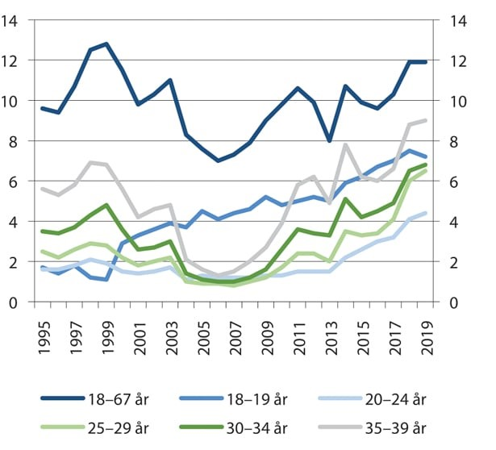

- sammenlignet med andre land er det en høy andel av den voksne befolkningen i Norge som mottar uføreytelser - det er ingenting som tyder på at den generelle helsetilstanden er dårligere i Norge enn i andre land - institusjonelle forskjeller som forklarer forskjellene i uføreandeler

## 6.2.1 Argument for offentlig **tvungen** sosialforsikring: Effektivitet 1: Regulering

- Hvorfor er medlemskapet obligatorisk?
  - Eksternaliteter
    - I mange tilfeller er beslutningen om å forsikre overlatt til individet, siden kostnadene ved ikke-forsikring faller på den enkelte
    - Men hvis noen velger å ikke forsikre seg mot inntektstap på grunn av arbeidsledighet eller dårlig helse, vil kostnadene falle på
      - ektefeller, barn og familie
      - skattebetalerne, for eksempel gjennom økende kriminalitet

      –> **negative eksternaliteter**
    - Når en aktivitet forårsaker en negativ eksternalitet, er en form for intervensjon en Pigou-skatt. Her er imidlertid målet å **hindre** manglende forsikring

    - Å gjøre forsikring obligatorisk (dvs. regulering) vil derfor være mest effektivt
  - I sum er det store effektivitetsargumentet for å gjøre medlemskap obligatorisk (=regulering) at **uforsikrede tap kan påføre kostnader (= negative eksternaliteter) for andre**

## 6.2.2 Argument for offentlig sosialforsikring: Effektivitet 2: offentlig tilbud

## Repetisjon: Privat tilbud av forsikring, forutsetninger

$$\pi_i = (1+α) p_iL$$

- De individuelle sannsynlighetene for ulykke/skade ($p_i$) er uavhengig av hverandre (ingen systematisk risiko)
- Må ha usikkerhet, dvs. manglende kunnskap om framtidig utfall $p_i \le 1$
  - om $p_i = 1$, da blir $\pi = (1+α)L > L$
- Risiko, ikke usikkerhet (sannsynlighet må være kjent eller mulig å estimere (forsikringsselskapet må vite gjennomsnittlig $p_i$)
- Ingen asymmetrisk informasjon
- ingen ugunstig utvalg
- ingen adferdsrisiko
  - Påvirke $p_i$ (ex ante atferdsrisiko)
    - forsikringstakeren kan påvirke sannsynlighet for tap eller størrelse på potensielt tap, gjennom strategisk adferdsendring
    - for eksempel ingen forebygging

### Arbeidsledighetstrygd (dagpenger): er forutsetningene for privat forsikring oppfylt?

- Det finnes systematisk risiko
- Framtidig utfall usikkert, $p_i < 1$
- Risikoen $p_i$ kan estimeres
- Problem med asymmetrisk informasjon
  - Ugunstig utvalg
    - – lavrisikogruppen vil ikke kjøpe forsikring
  - Adferdsrisiko
    - – forsikringstakeren kan påvirke $p_i$ => hva er den rette forsikringspremien?
      - Et sentralt spørsmål er hvor kostbart (økonomisk og psykisk) det er for en person å forbli arbeidsledig
        - den psykiske kostnaden for den enkelte kan være høy, og arbeidsledighet er forårsaket av mangel på jobber
          - en forsikringsbar risiko
        - den psykiske kostnaden er lav , og den enkelte forblir arbeidsledig delvis etter eget valg
          - en ikke-forsikringsbar risiko
        - $p_i$ kan manipuleres av den forsikrede personen på måter forsikringsgiveren ikke kan overvåke, noe som gjør det umulig for forsikringsselskapet å beregne en premie
  - dette problemet er verre for arbeidsledighetstrygd enn for sykepenger og uføretrygd
    - økonomisk teori: privat marked kan derfor ikke tilby arbeidsledighetstrygd

### Sykepenger og uføretrygd: er forutsetningene for privat forsikring oppfylt?

- usystematisk risiko (vanligvis): de individuelle sannsynlighetene $p_i$ er ikke relatert, bortsett fra under en stor epidemi
- framtidig utfall usikkert, $p_i < 1$ (ikke for kronisk syke)
- Risikoen $p_i$ kan estimeres
- Asymmetrisk informasjon
  - Ugunstig utvalg
    - ikke noe stort problem
    - et privat forsikringsselskap kan spørre om tidligere helse og fravær
    - sannsynligheten for fravær er stort sett eksogen, siden det **å gjøre seg selv** genuint syk er kostbart
    - påstått sykdom kan, i det minste opp til et punkt, kontrolleres ved å kreve at skadelidte skal fremlegge en legeerklæring
  - Adferdsrisiko
    - ikke et alvorlig problem
    - kan påvirke $p$
      - karensdag, lavere dekningsgrad
- økonomisk teori: Det er således ingen vesentlige problemer med privat tilbud av sykefraværsforsikring, og slike institusjoner finnes i mange land

## 6.2.4 Argument for offentlig sosialforsikring: Rettferdighet

- Horisontal ulikhet handler om minimumsstandarder for visse varer og/eller lik tilgang til dem
  - om forbrukere er godt informert –> ingen grunn til intervensjon pga. horisontal ulikhet
  - om de er dårlig informert, kan man argumentere for offentlig sosialforsikring både på grunn av rettferdighet og effektivitet
- Vertikal ulikhet handler om omfordeling fra rik til fattig
  - fordelingsmålene burde generelt oppnås gjennom inntektsoverføringer

## 6.3 Store spørsmål

- Skal sosialforsikringen være offentlig? Ja
  - Effektivitetsargumentene hviler på
    - negative eksternaliteter (rettferdiggjør **tvungen** sosialforsikring), og
    - asymmetrisk informasjon på tilbudssiden av forsikringsmarkedet (**rettferdiggjør offentlig tilbud**)
      - en svakere argument for sykepenger enn for de andre ytelsene
  - De viktigste rettferdighetsargumentene:
    - de fattige kan føle seg mindre stigmatisert av forsikring
    - hvis forsikring tilbys offentlig av effektivitetshensyn, kan den brukes som en omfordelingsanordning
  - Disse argumentene er overbevisende
    - noen forsikringer kunne tilbys av privat sektor - for eksempel kortsiktige sykepenger
- Gir staten den optimale mengden forsikring? Nei
  - trygden som tilbys er et gjennomsnitt som ikke tar hensyn til forskjeller i preferanser
  - spørsmålet er ikke im sosialforsikring er optimal, men at hvis den er godt utformet, er den mindre ineffektiv enn frimarkedsløsning.
- Er Folketrygden en forsikring?
  - Ytelsen er ikke knyttet til individuell risiko (avhengig av tidligere inntekt)
  - Retten til ytelse er ikke bare avhengig av forekomsten av den forsikrede hendelsen
  - Ordningens finansiering er ikke basert på vurderinger av risiki av forskjellige slag (sannsynlighetsfordelinger)
  - Kontrakten er ikke fullstendig spesifisert (risikoen som dekkes kan endres over tid)

## 6.3.2 Problem: Insentiveffekter

### Dagpenger: Andrea

### Sykepenger

#### kompensasjonsgrad

- Når sykefravær ikke innebærer noe direkte økonomisk tap for arbeidstaker, kan det bidra til høyere sykefravær
- en stram sykepengeordning, med lav kompensasjonsgrad, kan føre til at personer som ut fra helsetilstand og arbeidsevne ikke burde jobbe, likevel går på jobb
  - For vanlige årsaker til sykefravær som muskel- og skjelettlidelser og lettere psykiske lidelser vil likevel arbeid i mange tilfeller kunne være gunstig.
- en fallende kompensasjonsgrad i løpet av en sykepengeperiode vil gi arbeidstaker et økonomisk insentiv til å komme tilbake i arbeid
  - vil også gi arbeidstaker et økonomisk insentiv til å ha gradert sykmelding, siden lønnen er høyere enn sykepengene
  - Med full kompensasjon vil ikke arbeidstaker ha kortsiktige økonomiske gevinster ved gradering
- sykefravær påvirkes av andres fravær, som venner, naboer og kolleger
  - kan forsterke virkningen av økonomiske insentiver og andre faktorer som påvirker sykefraværet

### Sykefraværet og konjunkturer

- I den økonomisk litteraturen fokuseres det på tre forhold for å forklare konjunkturbevegelsene i sykefraværet: disiplineringseffekter, sammensetningseffekter og helseeffekter.

#### Disiplineringseffekt

- Arbeidsgivere vet at sykepenger kan gi arbeidstakere insentiver til å sykmelde seg uten å være (tilstrekkelig) syk
  - arbeidstakeren disiplineres av frykt for at arbeidsgiveren vil oppfatte fraværet som negativt.
- høy ledighet kan øke sannsynligheten for å miste jobben og gjøre det vanskeligere å finne nytt arbeid –> det å bli arbeidsledig vil få større konsekvenser enn når det er lav ledighet
- disiplineringseffekten virker sterkest når arbeidsledigheten er høy
- hindrer friske i å være borte fra jobben
- bidrar også til at syke går på jobb

#### Sammensetningseffekt

- oppstår ved at sysselsettingens sammensetning endres når aktivitetsnivået i økonomien endres
- Ved et høyt aktivitetsnivå vil mer marginale grupper være sysselsatt
  - Disse gruppene antas å ha mer fravær –> sykefraværet vil være høyere (lavere) i perioder med høy (lav) økonomisk aktivitet og høy (lav) sysselsetting

#### Helseeffekt

- hver enkelt arbeidstakers helse svinger med konjunkturene
  - flere kan føle seg utbrente i en høykonjunktur (lav ledighet) på grunn av at et høyt aktivitetsnivå på arbeidsplassen fører til økt fysisk og psykisk belastning

### Uføretrygd

- Kostøl og Mogstad (2014): sterkere økonomiske insentiver fører til at en viss andel av unge uføretrygdede kommer i jobb
- NOU 2021:2 - Kompetanse, aktivitet og inntektssikring — Tiltak for økt sysselsetting
  - Om lag 60 prosent av alle nye uføre har diagnoser innenfor psykiske lidelser eller sykdommer i muskel- og skjelett
  - Forskning og erfaring viser at arbeid i mange tilfeller kan være helsebringende ved denne typen diagnoser
    - en relativt lav andel av uføre i disse gruppene som er i arbeid
  - Det er godt dokumentert at tap av arbeid øker risikoen for å bli uføretrygdet
    - taler for at mange uføre ville kunne jobbe dersom de fikk en egnet jobb
    - Saksbehandleremener at flere uføre kunne kombinert uføretrygd og arbeid dersom forholdene lå bedre til rette for det
  - 23 000 uføre i dagens ordning oppgir selv at de ønsker å arbeide mer - I underkant av 20 prosent av de uføre har et arbeidsforhold
- Markussen og Røed (2021): Bidrar medikalisering av ungdom til utstøtning fra skole og arbeidsliv?
  - Det har vært en økende tilstrømning til helserelaterte trygdeytelser blant unge mennesker i Norge
    - en betydelig vekst i rapportering av psykiske helseproblemer blant barn og unge
    - indikasjoner på at den lokale tilbøyeligheten til å diagnostisere/utrede/behandle unge for psykiske lidelser
      - har negative effekter på skoleresultater
      - fører til lavere jobbsannsynlighet og høyere risiko for å være trygdemottaker i voksen alder
      - tolker dette som tegn på at sykdomsfokuset i noen grad kan ha blitt for framherskende
      - kan muligens være drevet fram av et underliggende ønske om sikring av rettigheter i velferdsstaten

## Problem: rettferdighet

- Horisontal likhet
  - Alle grupper får ikke lik dekning, for eksempel blir enker behandlet sjenerøst i forhold til familier som er skilt ved skilsmisse
  - Den relative behandlingen av menn og kvinner reiser spørsmål
- Vertikal likhet
  - Hvor omfordelende er folketrygden?
  - I de aller fleste OECD-land er den samlede effekten av skatter og overføringer redusert ulikhet betydelig